# NeuroDigits: Exploring Neural Networks for Handwritten Digit Recognition

## 👋 Introduction

[figure not shown]

In the realm of artificial intelligence, neural networks have emerged as powerful tools for pattern recognition and information processing. This notebook, titled "NeuroDigits: Exploring Neural Networks for Handwritten Digit Recognition," embarks on a journey to delve into the fascinating world of neural networks applied to the recognition of handwritten digits. Handwritten digit recognition serves as a foundational problem in computer vision and machine learning, representing a touchstone for the capabilities of neural networks. Through this exploration, I aim to unravel the basic principles behind neural networks, from the fundamental structure of neurons and layers to the intricate architectures that have revolutionized the field.

### 📖 Domain Understanding

- **Background**
- **Research**

### 📦 Data Provisioning

- **📋 Data Requirements**
- **🗂️ Data Collection**
- **📊 Data Understanding**
- **🛠️ Data Preparation**

### 🔮 Predictions

#### Feedforward neural network with 6 layers

- **🧹 Preprocessing**
- **🧬 Modelling**
- **🧐 Evaluation**

#### Convolutional Neural Network (CNN) with 9 layers

- **🧹 Preprocessing**
- **🧬 Modelling**
- **🧐 Evaluation**

#### Convolutional Neural Network (CNN) with 16 layers

- **🧬 Modelling**
- **🖼️ Data Augmentation**
- **🧐 Evaluation**

### 📝 Demonstration and Feedback

- **Demonstration**
- **Feedback**

## 📖 Domain Understanding

### Background

Handwritten digit recognition is a pivotal domain within the broader field of computer vision and pattern recognition. In essence, the task involves training machine learning models to accurately classify and discern numerals inscribed by hand. Beyond its inherent academic significance, the practical applications of this domain span various industries, including finance, postal services, and document analysis. For instance, in the realm of banking, automated reading of handwritten checks can streamline processes, while postal services leverage digit recognition for mail sorting.

### Research

**Main Question:**

How can we enhance the accuracy and interpretability of neural networks for recognizing handwritten digits?

**Sub-Questions:**

1. What types of neural network structures, like feedforward networks or convolution networks, work best for recognizing handwritten digits?
2. How do techniques like dropout and L1/L2 regularization help prevent the model from learning too much from the training data?
3. Could combining predictions from multiple models through ensemble methods lead to better results?

#### Research methods

| Research Method | Description |
| --- | --- |
| Literature Review | This method involves reviewing existing articles, documents, and reports. It provides a comprehensive understanding of existing knowledge and research findings in the field. |
| Available Product Analysis | This method consists of analyzing and evaluating existing products or services in the market. It helps identify trends, strengths, and areas for improvement in current offerings. |

**Introduction**

A neural network is a method in artificial intelligence that teaches computers to process data in a way that is inspired by the human brain. It is a type of machine learning process, called deep learning, that uses interconnected nodes or neurons in a layered structure that resembles the human brain. Artificial neural networks (ANNs) are comprised of a node layers, containing an input layer, one or more hidden layers, and an output layer. Each node, or artificial neuron, connects to another and has an associated weight and threshold. If the output of any individual node is above the specified threshold value, that node is activated, sending data to the next layer of the network. Otherwise, no data is passed along to the next layer of the network.

**Optimal Neural Network Structures**

**Preventing Overfitting with Regularization Techniques**

My findings reveal that techniques like dropout and L1/L2 regularization play pivotal roles in preventing overfitting during training. By introducing dropout, which randomly deactivates neurons, and applying regularization penalties to weights, the models strike a balance between accuracy and generalization, avoiding undue reliance on the training data.

**Ensemble Methods for Improved Predictions**

Combining predictions from multiple models through ensemble methods proves to be a powerful strategy for boosting recognition accuracy. Combining diverse models to mitigate individual weaknesses results in more robust and accurate predictions.

**Conclusion**

In conclusion, this research underscores the pivotal role of architecture, regularization techniques, ensemble methods for recognizing handwritten digits. These insights contribute not only to the academic understanding of neural network dynamics but also offer practical guidance for optimizing models in real-world applications. The pursuit of more accurate and interpretable models in handwritten digit recognition remains a dynamic and evolving field, with ongoing opportunities for exploration and refinement.

```python
import numpy as np
import matplotlib.pyplot as plt
import pandas as pd
import seaborn as sns
import umap

from sklearn.model_selection import train_test_split
from sklearn.preprocessing import StandardScaler

import tensorflow as tf
from tensorflow.keras import Sequential, layers, models
from tensorflow.keras.layers import Dense
from tensorflow.keras.regularizers import l2
from tensorflow.keras.utils import to_categorical, plot_model
from tensorflow.keras.layers import Dropout, BatchNormalization
from keras.preprocessing.image import ImageDataGenerator

# this is for the function to save the models' architectures into images
import os
os.environ["PATH"] += os.pathsep + 'C:/Program Files/windows_10_msbuild_Release_graphviz-9.0.0-win32/Graphviz/bin'
os.environ["TF_KERAS"] = "1"
```

## 📦 Data provisioning

We will look at the fundamentals of data provisioning in this part. As my previous project, I decided to follow the AI Project Methodology to create a structured notebook. However, due to time limits, we will not delve that deep into every single step. In this part, we will talk about data sourcing, transformation, integration and quality. The 4 main parts of Data Provisioning are going to be Data Requirements, Data Collection, Data Understanding and Data Preparation.

### 📋 Data Requirements

#### Data Elements

- Numerical Data:
  - Data Type: Numerical
  - Example: Pixel intensity values
  - Units: Grayscale values (0 to 255)
  - Range: 0 to 255
- Categorical Data:
  - Data Type: Categorical
  - Example: Digit labels
  - Categories: 0 to 9
- Image Data:
  - Data Type: Image
  - Derivation: Composed of pixel intensity values
  - Size: 28x28 pixels
  - Content: Grayscale representation of handwritten digits
  - Digit Range: 0 to 9 (The digit within the image should be one of the numbers from 0 to 9)

#### Data Volume

The estimated sufficient training data volume is 60,000. It is important to consider the complexity of digit recognition tasks and find a suitable balance.

#### Data Quality Standards

The Data Quality Standards are accuracy, completeness and consistency for this project. Another important aspect is to validate the data to detect outliers and errors.

#### Data Dictionary

##### Pixel Intensity

- **Data Element Name:** Pixel Intensity
- **Data Type:** Numerical
- **Units:** Grayscale Values (0 to 255)
- **Range:** 0 to 255
- **Description:** Intensity of pixels in the image
- **Source:** MNIST Dataset
- **Quality Standards:** N/A
- **Notes:** Values between 0 and 255.

##### Digit Label

- **Data Element Name:** Digit Label
- **Data Type:** Categorical
- **Units:** N/A
- **Range:** 0 to 9
- **Description:** Label indicating the digit in the image
- **Source:** MNIST Dataset
- **Quality Standards:** Correct labeling
- **Notes:** Categories: 0 to 9

##### Image

- **Data Element Name:** Image
- **Data Type:** Image
- **Units:** N/A
- **Range:** N/A
- **Description:** Handwritten digit image
- **Source:** MNIST Dataset
- **Quality Standards:** High-resolution, clear images preferred, the digit displayed to be from 0 to 9
- **Notes:** 28x28 pixel size

### 🗂️ Data Collection

Data Collection is a foundational step in AI. The aim is to acquire a representative and informative dataset that enables the ML model to understand patterns and make accurate predictions.

#### Collect the Data

There are many available sources, but I decided on Kaggle and the publicly available datasets.

#### Data Storage

Data storage is extremely important for the project. At this point, I am storing my data in local storage. Cloud is also a suitable option that can be considered in the future if the dataset becomes larger in the future.

#### MNIST Dataset

The MNIST database (Modified National Institute of Standards and Technology database) is a large database of handwritten digits that is commonly used. It was created by re-mixing samples from NIST's original datasets. The MNIST database contains 60,000 training images and 10,000 testing images. Half of the training set and half of the test set were taken from NIST's training dataset, while the other half of the training set and the other half of the test set were taken from NIST's testing dataset. The set of images in the MNIST database was created in 1994 as a combination of two of NIST's databases: Special Database 1 and Special Database 3. Special Database 1 and Special Database 3 consist of digits written by high school students and employees of the United States Census Bureau, respectively.

The orginal dataset is in a format that can be difficult to use. The dataset that I will be using is provided from Joseph Redmon in a CSV format. I will be using 2 files - mnist_train.csv which is the training set, and mnist_test.csv which is the testing set. Each row consists of 785 values: the first values is the label (a number from 0 to 9) and the remaining 784 values are pixel values (a number from 0 to 255).

### 📃 Sample the data

Let's take a quick look at our data. We have 2 separate datasets for training and testing. The train_data is going to be our training DataFrame. It consists of 60000 rows and 785 columns. One of the columns is our label, aka which number is on the picture. The other columns are the pixels. The same goes for the test_data with the only difference that it has 10000 values.

```python
train_data = pd.read_csv('mnist_train.csv')
test_data = pd.read_csv('mnist_test.csv')
```

```python
print("Training Dataset:")
print(train_data.head())
```

```
Training Dataset:
   label  1x1  1x2  1x3  1x4  1x5  1x6  1x7  1x8  1x9  ...  28x19  28x20  \
0      5    0    0    0    0    0    0    0    0    0  ...      0      0
1      0    0    0    0    0    0    0    0    0    0  ...      0      0
2      4    0    0    0    0    0    0    0    0    0  ...      0      0
3      1    0    0    0    0    0    0    0    0    0  ...      0      0
4      9    0    0    0    0    0    0    0    0    0  ...      0      0

   28x21  28x22  28x23  28x24  28x25  28x26  28x27  28x28
0      0      0      0      0      0      0      0      0
1      0      0      0      0      0      0      0      0
2      0      0      0      0      0      0      0      0
3      0      0      0      0      0      0      0      0
4      0      0      0      0      0      0      0      0

[5 rows x 785 columns]
```

### 📊 Data Understanding

In this step, we are going to explore the dataset, see our labels and values and do as much exploration as we can.

```python
train_data.info()
```

```
<class 'pandas.core.frame.DataFrame'>
RangeIndex: 60000 entries, 0 to 59999
Columns: 785 entries, label to 28x28
dtypes: int64(785)
memory usage: 359.3 MB
```

```python
test_data.info()
```

```
<class 'pandas.core.frame.DataFrame'>
RangeIndex: 10000 entries, 0 to 9999
Columns: 785 entries, label to 28x28
dtypes: int64(785)
memory usage: 59.9 MB
```

```python
print(f"Number of Classes:", test_data.label.nunique())
```

```
Number of Classes: 10
```

```python
np.isnan(train_data).any()
```

```
label    False
1x1      False
1x2      False
1x3      False
1x4      False
         ...
28x24    False
28x25    False
28x26    False
28x27    False
28x28    False
Length: 785, dtype: bool
```

```python
np.isnan(test_data).any()
```

```
label    False
1x1      False
1x2      False
1x3      False
1x4      False
         ...
28x24    False
28x25    False
28x26    False
28x27    False
28x28    False
Length: 785, dtype: bool
```

```python
print(train_data['label'].value_counts())
```

```
label
1    6742
7    6265
3    6131
2    5958
9    5949
0    5923
6    5918
8    5851
4    5842
5    5421
Name: count, dtype: int64
```

In the next plot, we can see the distribution of the digits in the training and in the test data. We can see that we have an enough amount of values for each digit. Some of them have more than the others, but this is completely normal.

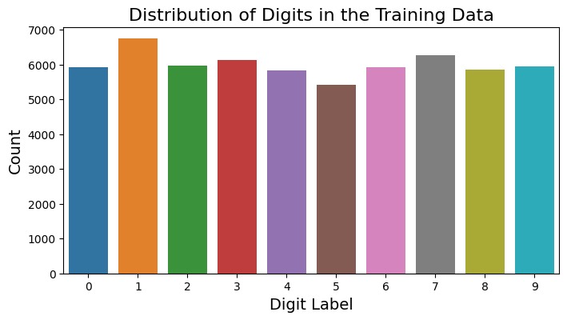

```python
plt.figure(figsize=(8, 4))

sns.countplot(data=train_data, x='label')

plt.xlabel("Digit Label", fontsize=14)
plt.ylabel("Count", fontsize=14)
plt.title("Distribution of Digits in the Training Data", fontsize=16)

plt.show()
```

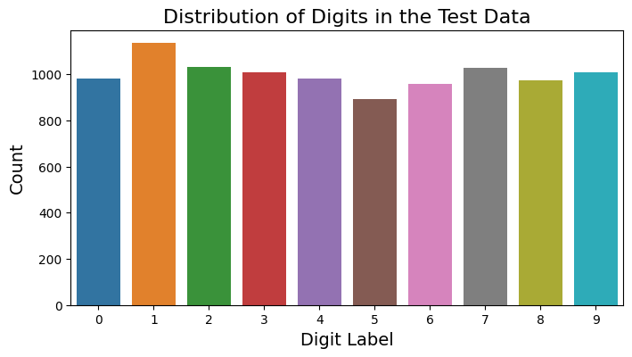

```python
plt.figure(figsize=(8, 4))

sns.countplot(data=test_data, x='label')

plt.xlabel("Digit Label", fontsize=14)
plt.ylabel("Count", fontsize=14)
plt.title("Distribution of Digits in the Test Data", fontsize=16)

plt.show()
```

In the next plots, we are going to see some samples of the images in the datasets.

```python
def display_samples(data, title):
    plt.figure(figsize=(10, 6))
    for i in range(10):
        plt.subplot(2, 5, i+1)
        plt.imshow(data.iloc[i, 1:].to_numpy().reshape(28, 28), cmap='gray')
        plt.title(f"Label: {data.iloc[i, 0]}")
        plt.axis('off')
    plt.suptitle(title)
    plt.show()
```

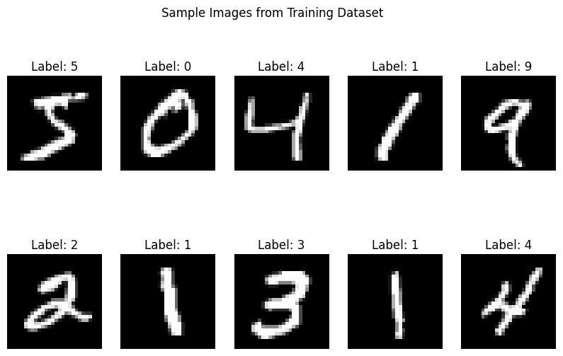

```python
display_samples(train_data, 'Sample Images from Training Dataset')
```

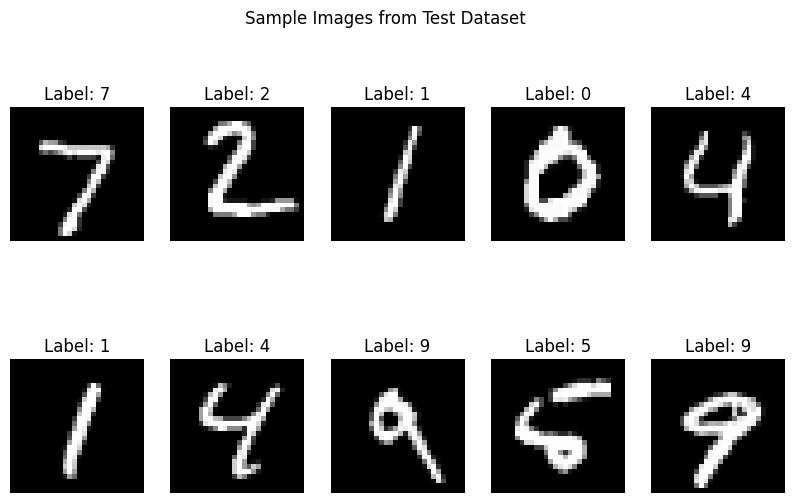

```python
display_samples(test_data, 'Sample Images from Test Dataset')
```

Now, we are going to see each digit to see the difference between handwritting and assess properly how this is going to affect the model.

```python
def display_samples_by_label(data, label, title):
    plt.figure(figsize=(10, 6))

    data_label = data[data.iloc[:, 0] == label].head(10)

    for i in range(10):
        plt.subplot(2, 5, i+1)
        plt.imshow(data_label.iloc[i, 1:].to_numpy().reshape(28, 28), cmap='gray')
        plt.title(f"Label: {data_label.iloc[i, 0]}")
        plt.axis('off')

    plt.suptitle(title)
    plt.show()
```

Let's dig deeper into the world of handwritten numbers by looking at 10 different samples for each digit. Each person has their own unique way of writing, but it's interesting to note that all the digits we're studying come from people in the United States. This might mean they were taught to write in a similar way.

But here's the cool part: handwriting isn't just about the person. It also depends on the situation. Imagine filling out a form in a hurry – your writing might look different, and you might even have trouble recognizing it yourself!

Our dataset comes from real documents, making it realistic but sometimes tricky. There are moments where even a person might struggle to figure out which digit is which. This mix of personal styles and real-world situations adds a layer of complexity. It highlights the challenge of creating a smart system that can tell the difference between digits, no matter how they're written.

It is important to note these downsides of the dataset and the task before putting into a machine learning model. Knowing the pitfalls and understanding what we can control and what not is crucial for each task.

The first digit is the 0. Zeros are usually easy to write. It can be an opened or closed circle, and slimmer or wider cirlce. When in a rush, if the circle is not closed and the top goes a bit higher, it can be easily interpreted as a 6.

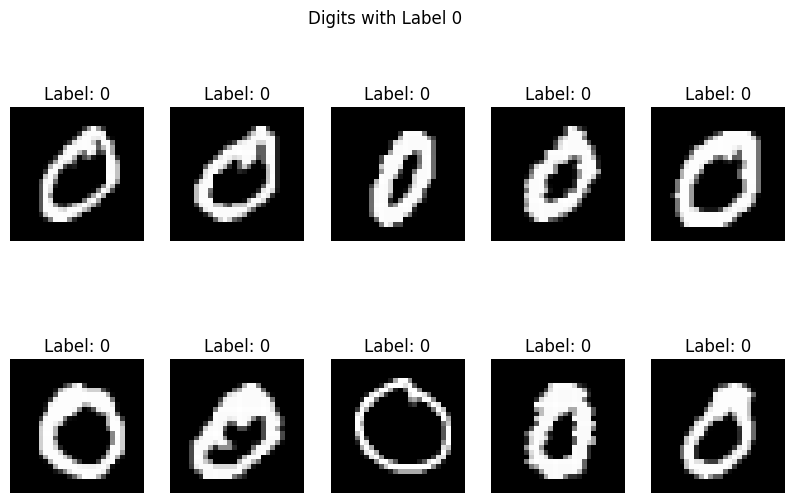

```python
display_samples_by_label(train_data, 0, "Digits with Label 0")
```

The next digit is 1. There is a variation on how to write it as we can see from the sample. It can be only one straight line, and 1 or 2 more lines can be added. This can differ from person to person, and the way they are taught. if the digit is written with 2 lines, without the line in the bottom, it can be easily mistaken for a 7.

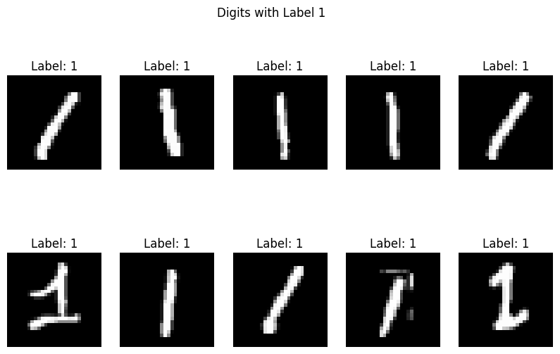

```python
display_samples_by_label(train_data, 1, "Digits with Label 1")
```

Now, we are going to explore the variations of the digit 2. What we can see in the sample below, is that the most common variation is the loop at the bottom of the digit. If there is indeed a loop, the digit can be confused with 6 and 8.

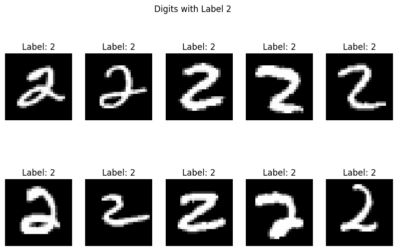

```python
display_samples_by_label(train_data, 2, "Digits with Label 2")
```

We are continuing with the digit 3. The variations here come with the size and curvature of the loop. Also, some people write the top part flat, as we can see from the picture. This digit is most commonly mistakened with 5.

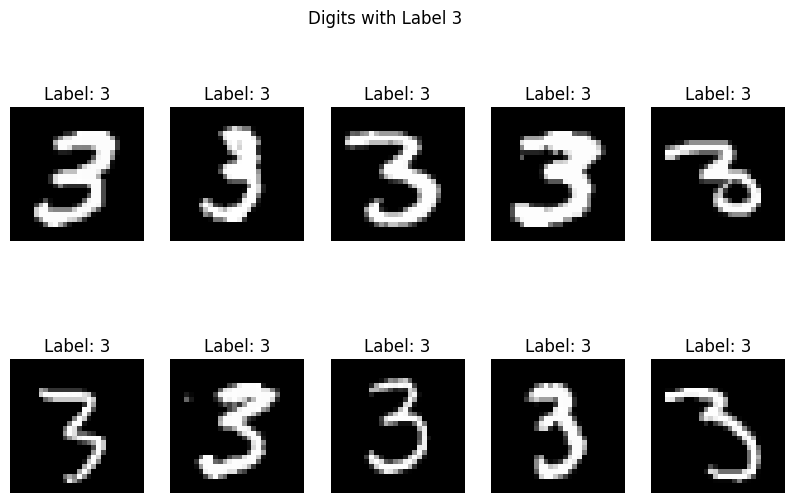

```python
display_samples_by_label(train_data, 3, "Digits with Label 3")
```

We are going further with the digit 4. Here, the variations are the length and angle of the strokes. Sometimes, it can be confused with a 9.

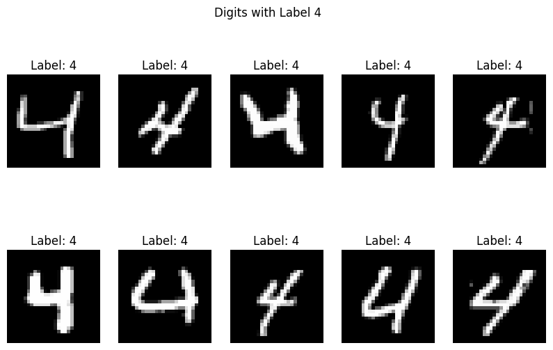

```python
display_samples_by_label(train_data, 4, "Digits with Label 4")
```

The digit 5 can have different loop size and position. Usually, it can be mistaken for a 6, depending on the loop and the angle of connection.

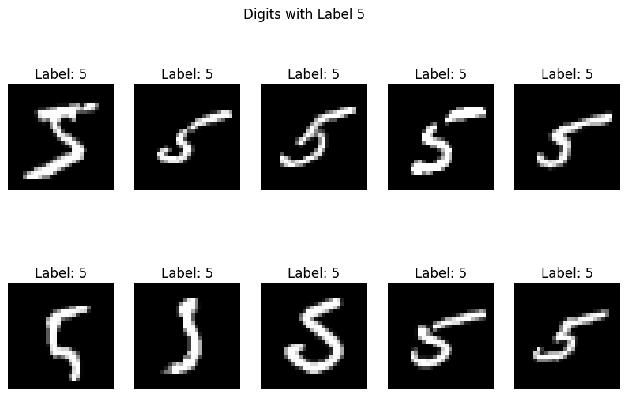

```python
display_samples_by_label(train_data, 5, "Digits with Label 5")
```

Next, we are going to look at the digit 6. The variations that can occur hee are in the loop size, angle of connection and openness of the top loop. If you are writing fast, 0 and 6 can be written sometimes almost the same. If the loop is bigger on the 6, the digit can be interpeted as a 0.

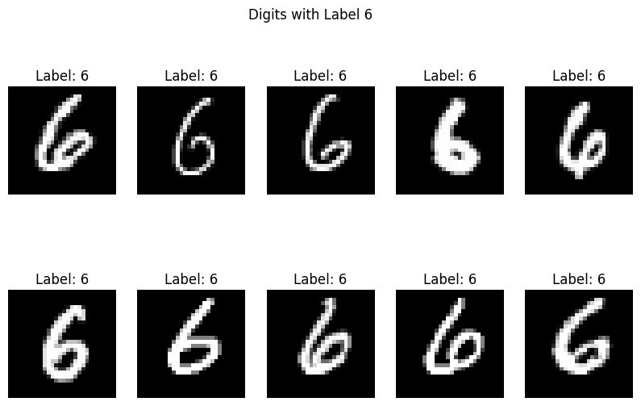

```python
display_samples_by_label(train_data, 6, "Digits with Label 6")
```

Now, let's look at the 7. It can be written with 2 or 3 lines. If there is a third line that is crossing the digit, it distinguishes that the digit is 7. However, without that middle line, it is common to confuse it with 1.

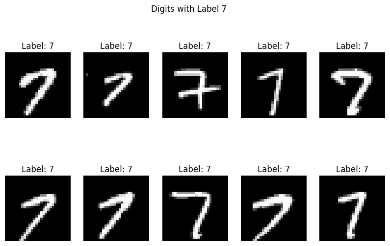

```python
display_samples_by_label(train_data, 7, "Digits with Label 7")
```

The digit 8 consists of 2 loops. The variations can occur in the size and shape of them. Sometimes even, the loops can be unfinished. In these cases, the digit can be mistaken for a 3 or a 9.

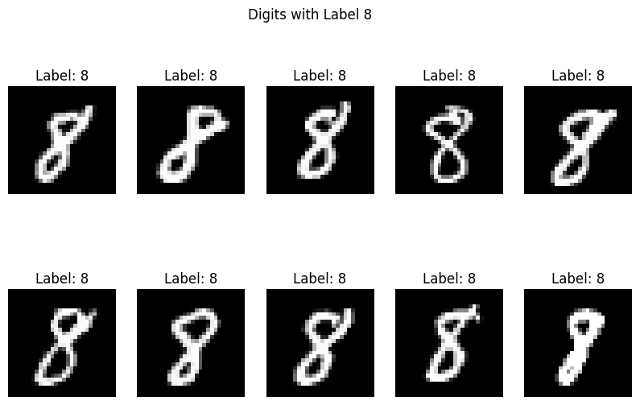

```python
display_samples_by_label(train_data, 8, "Digits with Label 8")
```

Lastly, we are looking at the digit 9. It consists of 1 loop. The variations can occur not only at the size of the loop, but at the length and angle of the stroke that is finishing the digit. The most common mistakes that can occus is to interpet the digit as a 4 or an 8.

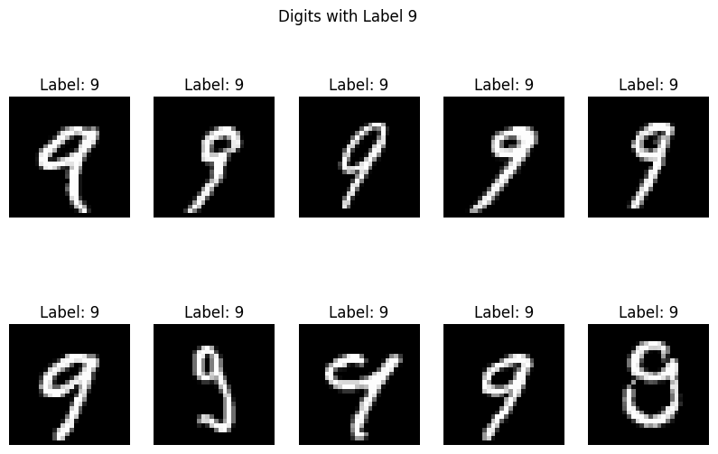

```python
display_samples_by_label(train_data, 9, "Digits with Label 9")
```

In summary, each digit boasts its own unique handwriting, and it's highly unlikely to find two identical instances. The variability in how people write digits, coupled with the diverse circumstances under which they're written, can make interpretation challenging. Even within our sampled data, we encounter instances of digits that can be perplexing.

Take, for example, the resemblance between some 7s and 1s. Without the context of knowing it's a sample of the digit 7, there's a real risk of confusing it with a 1. This realization becomes crucial for our process – acknowledging that not every digit in our dataset is crystal clear. Nevertheless, armed with this insight, our goal remains the same: to train a model capable of successfully distinguishing these varied handwritten digits.

### 🛠️ Data Preparation

For this section, it is important to note that our dataset matches the data requirements that we have defined for the task. This means, we do not have much data preparations steps. The dataset is consistent in the labeling, there are no missing or null values. We have everything that we need to train a model. The only needed actions from our side is to reshape the images to match the expected format of the neural network model.

The dataset, originally organized as rows of pixel values for each image, undergoes a preparation pipeline to split it into input features (X_train and X_test) and corresponding labels (y_train and y_test). This initial step sets the stage for organizing the data into features and labels, essential components for training and evaluating a neural network model.

```python
# Training data preparation
X_train = train_data.drop(columns=['label']).values
y_train = train_data['label'].values.reshape((-1, 1))
```

```python
# Testing data preparation
X_test = test_data.drop(columns=['label']).values
y_test = test_data['label'].values.reshape((-1, 1))
```

## Feedforward neural network with 6 layers

The feedforward neural network using Keras is designed for simplicity and ease of use. The architecture consists of several dense layers, each followed by a rectified linear unit (ReLU) activation function, which introduces non-linearity and allows the network to learn complex patterns. The model follows a sequential structure, with the layers stacked one after the other. Although straightforward, this model showcases the foundational elements of neural network design, making it suitable for introductory purposes or tasks where a relatively simple architecture is sufficient.

### 🧹 Preprocessing

In the next code, we are going to preprocess the X_train and X_test. We are going to reshape and normalize the data for the machine learning model. Firstly, we are going to reshape the data, so each data point in the dataset represents a 28x28 pixel image. The division by 255 is a normalization step, scaling the pixels between 0 and 1. Then we are going to flatten the 28x28 grid into a one-dimensional array with 28x28 elements.

```python
# Reshape and normalize training data
X_train = X_train.reshape((-1, 28, 28)).astype('float32') / 255
X_train = X_train.reshape((-1, 28*28))

# Reshape and normalize testing data
X_test = X_test.reshape((-1, 28, 28)).astype('float32') / 255
X_test = X_test.reshape((-1, 28*28))
```

```python
y_train.shape
```

```
(60000, 1)
```

```python
X_train.shape
```

```
(60000, 784)
```

```python
X_train[0].shape
```

```
(784,)
```

The next code is using a function from Keras to convert the categorical labels into one-hot encoded vectors. Each label is transformed into a binary vector with a length equal to the number of classes. The element corresponding to the actual class is set to 1, while all other elements are set to 0.

```python
y_train = to_categorical(y_train)
y_test = to_categorical(y_test)
```

### 🧬 Modelling

The model we are going to create is a feedforward neural network using the Keras Sequential API. This is one of the simplest approaches in neural networks. The model consists of three dense fully connected layers with ReLU functions and dropout layers for regularization. Regularization, ReLU (Rectified Linear Unit), and dropout are techniques used in neural networks to improve their generalization performance, prevent overfitting, and enhance training stability.

ReLU is an activation function commonly used in neural networks. It replaces all negative values in the input with zero and leaves positive values unchanged. Mathematically, the ReLU activation function is defined as f(x)=max(0,x). ReLU reduces non-linearity to the model, allowing it to learn complex relationships in the data. Recognizing digits involves learning complex, non-linear relationships between pixel values in the input images and the corresponding digit labels.

For the initializer, we are using He initialization. It is a specific weigth initialization technique and helps with the stable and efficient training of deep neural networks, especiall those using acitvation functions like ReLU.

To prevent overfitting, there are a couple of techniques to be implemented. The regularization for each neural network and each task can differ a lot. It is important to find a suitable balance, where the model is performing well, but is not overfitting. One of the ways to prevent overfitting and enhance the model robustness is dropout. It works by randomly setting to 0 a fraction of the neurons in a layer during each training iteration. Another one of the techniques is the kernel regularization L2. It forces the model to focus on essential features and avoid fitting the noise in the training data.

The last layer uses the softmax activation function, indicating that the model is designed for a multi-class classification task with 10 output classes.

```python
model = Sequential()

model.add(layers.Dense(128, activation='relu', kernel_initializer='he_normal', kernel_regularizer=l2(0.01), input_shape=(28*28,)))
model.add(layers.Dropout(0.2))
model.add(layers.Dense(64, activation='relu', kernel_initializer='he_normal', kernel_regularizer=l2(0.01)))
model.add(layers.Dropout(0.1))
model.add(layers.Dense(32, activation='relu', kernel_initializer='he_normal', kernel_regularizer=l2(0.01)))
model.add(layers.Dense(10, activation='softmax'))
```

```python
model.summary()
```

[output not shown]

Furthermore, we can see a plot with the model's structure that gives a clear overview of the layers, the input and output of them.

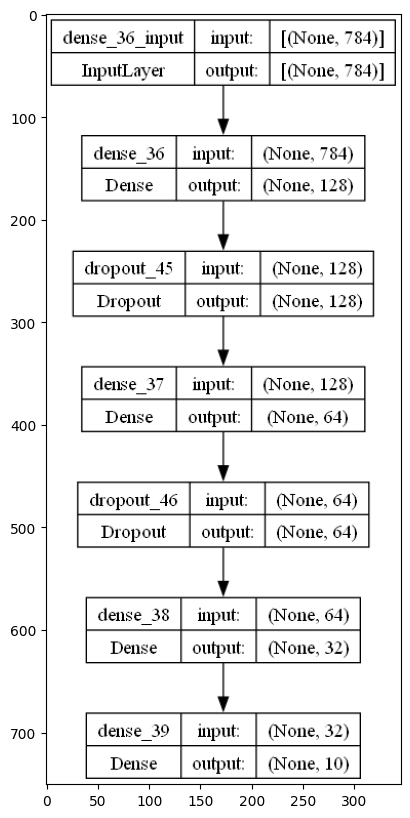

```python
plot_model(model, to_file='neuro_models/model_plot.png', show_shapes=True, show_layer_names=True)

img = plt.imread('neuro_models/model_plot.png')
fig, ax = plt.subplots(figsize=(10, 10))
ax.imshow(img)
plt.show()
```

In the next code, we are configuring and preparing the model for training using the Keras library. The model.compile is used to specify key training parameters. The optimizer, defined as 'adam', is a popular choice for adaptive learning rate optimization. The loss function, set to 'categorical_crossentropy', is suitable for multi-class classification tasks like digit recognition. This function quantifies the difference between predicted and true class probabilities, guiding the network to minimize this difference during training. Finally, 'accuracy' is chosen as a metric to monitor during training, providing a straightforward measure of the model's classification performance.

```python
model.compile(optimizer='adam', loss='categorical_crossentropy', metrics=['accuracy'])
```

Finally, we are training the model with the next code. The input features are the X_train and the corresponding labels are are y_train. The training process occurs over a specified number of epochs (10 in this case), where each epoch represents one complete pass through the entire training dataset. The batch_size parameter determines the number of samples processed in each iteration, and a validation split of 20% is used to assess the model's performance on a separate portion of the training data, serving as a proxy for its generalization to unseen data. The verbose argument set to 1 enables the display of training progress information, such as epoch number, training loss, and validation metrics.

```python
model_history = model.fit(X_train, y_train, epochs=10, batch_size=128, validation_split=0.2, verbose=1)
```

### 🧐 Evaluation

```python
test_loss, test_acc = model.evaluate(X_test, y_test)
print(f'Test Accuracy: {test_acc}')
```

```
Test Accuracy: 0.9476000070571899
```

The next plot that we are going to do is vital for our process. It is going to help us determine if the model is learning well and if it is overfitting. The plot visualizes the training and validation loss across different epochs. The training loss curve indicates how well the model is fitting the training data over successive epochs, aiming to minimize the loss. On the other hand, the validation loss reflects the model's performance on a separate portion of the data not used for training, providing insigths into its generalization to new, unseen samples. Ideally, both training and validation loss should decrease over epochs. If the training loss decreses while the validation loss increses, it could be a sign of overfitting. Additionally, if lines remain high or decrease slowly, the model might be underfitting.

This plot has helped me a lot in the creation of an accurate neural network model. When I initially started this notebook, I created a model that had no regularization. The model had high accuracy and it seemed that it was performing well. However, I found this plot, and when I did it, I understood that my model is extremely overfitting. Looking at this plot after every change I make of the parameters in the model or the data, helps me a lot to determine if I am in the right direction and if the model is learning well.

In summary, the loss plot is a valuable diagnostic tool for assessing the model's training progress and generalization performance. It helps identify potential issues and guides adjustments to the model architecture or training parameters.

```python
def plot_loss(history):
    plt.plot(history.history['loss'], label='Training Loss')
    plt.plot(history.history['val_loss'], label='Validation Loss')
    plt.xlabel('Epoch')
    plt.ylabel('Loss')
    plt.legend()
    plt.show()
```

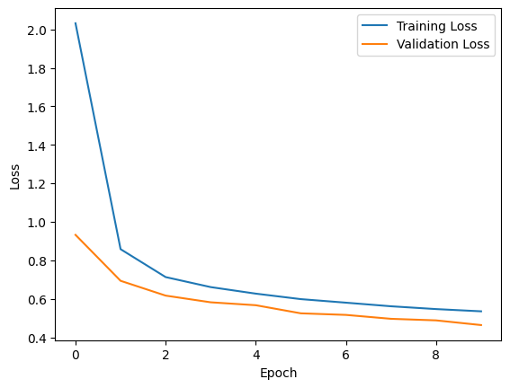

```python
plot_loss(model_history)
```

Lastly, let's see the actual predictions for the test data, alongside with the number of the errors the model made.

```python
predictions = model.predict(X_test)
```

```python
true_labels = np.argmax(y_test, axis=1)
predicted_labels = np.argmax(predictions, axis=1)
```

```python
misclassified_indices_f = np.where(predicted_labels != true_labels)[0]
```

```python
misclassified_predictions_f = predicted_labels[misclassified_indices_f]
```

We can see that the model, although it has good accuracy and it is not overfitting, made a lot of errors.

```python
misclassified_predictions_f.sum()
```

```
2568
```

On the next plot, we can see a sample of 10 images with their true and predicted label. The image that we need to pay attention to is on the second row, the second to last digit (the only digit that is predicted incorrectly in the sample). We can see that this digit is quite hard to recognize even for us, if we hadn't seen the true label. Further, we will see how the next models predict that digit.

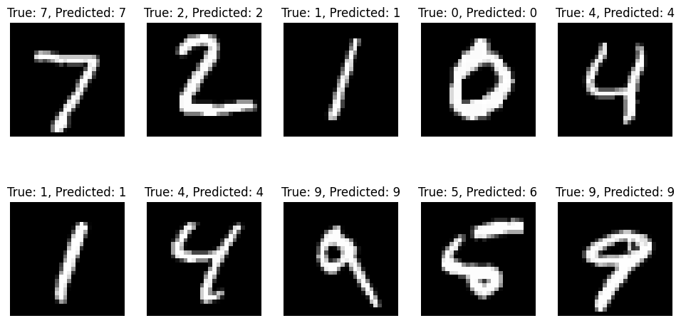

```python
plt.figure(figsize=(12, 6))
for i in range(10):
    plt.subplot(2, 5, i + 1)
    plt.imshow(X_test[i].reshape(28, 28), cmap='gray')
    plt.title(f"True: {true_labels[i]}, Predicted: {predicted_labels[i]}")
    plt.axis('off')

plt.show()
```

## Convolutional Neural Network (CNN) with 9 layers

The Convolutional Neural Network (CNN) is again constructed using the Keras Sequential API. Unlike the simplicity of a feedforward network, CNN is specialized for tasks involving grid-like data such as images. This architecture employs convolutional layers that systematically scan the input image, capturing local patterns through convolutional operations. These convolutional layers are interleaved with max-pooling layers, reducing spatial dimensions and preserving important features. The network is designed to learn hierarchical representations of the input data, enhancing its ability to recognize complex visual patterns.

### 🧹 Preprocessing

For the preprocessing step here, we need to reshape the images again. CNNs are particularly effective for image-related tasks, and their input format typically involves a three-dimensional structure representing the image dimensions along with the number of channels. So, the reshaped datasets X_train_cnn and X_test_cnn are now three-dimensional arrays representing images suitable for input into a CNN.

```python
X_train_cnn = X_train.reshape((-1, 28, 28, 1))
X_test_cnn = X_test.reshape((-1, 28, 28, 1))
```

```python
X_train_cnn.shape
```

```
(60000, 28, 28, 1)
```

```python
X_train_cnn[0].shape
```

```
(28, 28, 1)
```

### 🧬 Modelling

As mentioned, CNN is a more complex neural network model, so let's think of CNN as a smart robot learning to recognize handwritten numbers. With that said, now we are going to break down each part:

- Layer 1: The robot looks at the picture and spots simple shapes. It uses 32 different filters to focus on different feauters like strokes and curves.
- Max Pooling 1: The robot takes a step back and looks at the bigger picture, finding the most important indormation, then it compresses the image a bit to keep the important details.
- Layer 2: We are going deeper. The robot tries to understand more complex patterns and now it uses 64 filters to capture more features.
- Max Pooling 2: We are zooming out again. The robot reduces the image size while keeping the essential features intact.
- Layer 3: The robot goes even deeper.
- Flatten Layer: The robot organizes all the information.
- Fully Connected Layer 1: The robot looks at the overall picture and tries to understand what it sees. At this layer, we are also adding regularization to prevent overfitting.
- Dropout Layer: The robot wants to make sure it is not getting too obseessed with tiny details. It randomly ignores some of its observations (40% of them) to stay more balanced.
- Fully Connected Layer 2 (Output Layer): The robot is ready to give an answer. It makes a final decision and picks the most likely answer.

This explanation is as simplified as possible, so my work is transparent and understandable by everyone. CNNs can be hard to understand, but once you do, they are extremely useful and go way deeper than the feedforward networks.

```python
cnn = models.Sequential()

# First conv layer followed by max pooling
cnn.add(layers.Conv2D(32, (3,3), activation='relu', kernel_initializer='he_normal', input_shape=(28, 28, 1)))
cnn.add(layers.MaxPooling2D((2,2)))

# Second conv layer followed by max pooling
cnn.add(layers.Conv2D(64, (3,3), activation='relu', kernel_initializer='he_normal'))
cnn.add(layers.MaxPooling2D(2,2))

# Third conv layer
cnn.add(layers.Conv2D(64, (3,3), activation='relu', kernel_initializer='he_normal'))

# Fully connected layers
cnn.add(layers.Flatten())
cnn.add(layers.Dense(128, activation='relu', kernel_initializer='he_normal', kernel_regularizer=l2(0.01)))
cnn.add(layers.Dropout(0.4))
cnn.add(layers.Dense(10, activation='softmax'))
```

We are once again going to see the summary of the model, as well as a plot with the model's architecture and information about each of the layers.

```python
cnn.summary()
```

[output not shown]

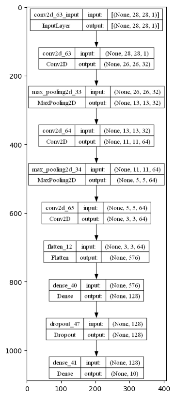

```python
plot_model(cnn, to_file='neuro_models/model_plot_cnn.png', show_shapes=True, show_layer_names=True)

img_cnn = plt.imread('neuro_models/model_plot_cnn.png')
fig, ax = plt.subplots(figsize=(10, 10))
ax.imshow(img_cnn)
plt.show()
```

The next line of code configures the training process for the CNN. We specify optimizer, loss function, and evaluation metric. The 'adam' optimizer is chosen for efficient weight updates during training. The 'categorical_crossentropy' loss function is apt for multi-class classification tasks like digit recognition, measuring the difference between predicted and true class distributions. Lastly, the 'accuracy' metric tracks the model's classification performance during training, indicating the proportion of correctly predicted instances.

```python
cnn.compile(optimizer='adam', loss='categorical_crossentropy', metrics=['accuracy'])
```

Now, we are going to initiate the training for the CNN. The training process occurs over 10 epochs, representing complete passes through the entire training dataset. With a batch size of 128, the model updates its weights and biases after processing each batch of training samples. The 'validation_split' parameter designates 20% of the training data for validation, allowing the model to assess its performance on a separate set and detect potential overfitting. The 'verbose' setting at 1 enables the display of training progress, including epoch number, training loss, and validation metrics.

```python
cnn_history = cnn.fit(X_train_cnn, y_train, epochs=10, batch_size=128, validation_split=0.2, verbose=1)
```

### 🧐 Evaluation

Now, we are going to evaluate the model's performance using the Accuracy and the previously shown plot for the training loss and validation loss. Overall, the model is performing well.

```python
test_loss_cnn, test_accuracy_cnn = cnn.evaluate(X_test_cnn, y_test)
print(f'Test Accuracy: {test_accuracy_cnn}')
```

```
Test Accuracy: 0.9915000200271606
```

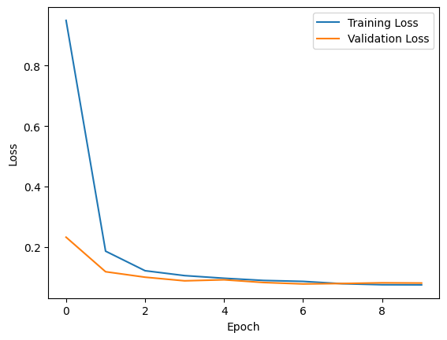

```python
plot_loss(cnn_history)
```

Now, once again let's see the predictions for the test data, as well as the errors that the model made.

```python
predictions_cnn = cnn.predict(X_test_cnn)
```

```python
true_labels_cnn = np.argmax(y_test, axis=1)
predicted_labels_cnn = np.argmax(predictions_cnn, axis=1)
```

```python
misclassified_indices_cnn = np.where(predicted_labels_cnn != true_labels_cnn)[0]
```

```python
misclassified_predictions_cnn = predicted_labels_cnn[misclassified_indices_cnn]
```

```python
misclassified_predictions_cnn.sum()
```

```
388
```

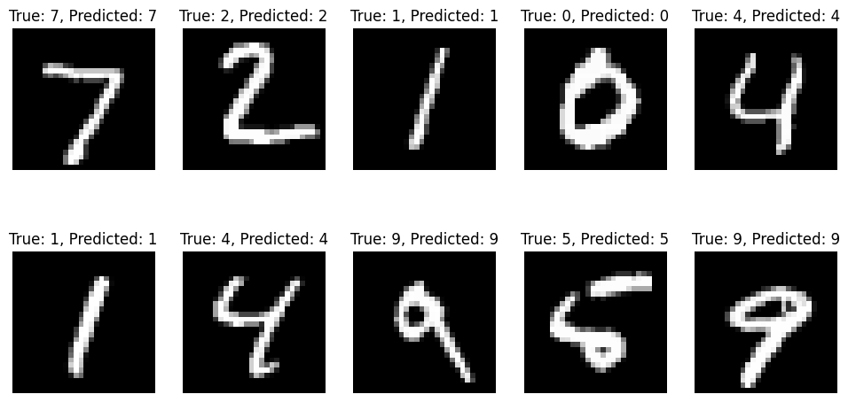

```python
plt.figure(figsize=(12, 6))
for i in range(10):
    plt.subplot(2, 5, i + 1)
    plt.imshow(X_test_cnn[i].reshape(28, 28), cmap='gray')
    plt.title(f"True: {true_labels_cnn[i]}, Predicted: {predicted_labels_cnn[i]}")
    plt.axis('off')

plt.show()
```

This model has a really good performance and the errors dropped significantly. The model is not that complex, but it gives really good results, so sometimes simplicity can win over complexity. We can also see that the problematic digit on the second row is correctly classified as a 5.

## Convolutional Neural Network (CNN) with 16 layers

Now, let's discuss our final model in this notebook. This neural network is a CNN with 16 layers, designed to excel in recognizing handwritten digits. Our main goal throughout this project has been to understand how neural networks work, and this model, being more complex, has proven to be effective. We won't delve into the details of each layer's creation, as we've covered that before. Instead, let's focus on the overall architecture and its success in handling the nuances of recognizing handwritten digits.

### 🧬 Modelling

```python
cnn_16_layers = Sequential()

cnn_16_layers.add(layers.Conv2D(filters=32, kernel_size=(5, 5), padding='Same', activation='relu', input_shape=(28, 28, 1)))
cnn_16_layers.add(layers.Conv2D(filters=32, kernel_size=(5, 5), padding='Same', activation='relu'))
cnn_16_layers.add(layers.MaxPooling2D(pool_size=(2, 2)))
cnn_16_layers.add(Dropout(0.25))

cnn_16_layers.add(layers.Conv2D(filters=64, kernel_size=(3, 3), padding='Same', activation='relu'))
cnn_16_layers.add(layers.Conv2D(filters=64, kernel_size=(3, 3), padding='Same', activation='relu'))
cnn_16_layers.add(layers.MaxPooling2D(pool_size=(2, 2)))
cnn_16_layers.add(Dropout(0.25))

cnn_16_layers.add(layers.Conv2D(filters=128, kernel_size=(3, 3), padding='Same', activation='relu'))
cnn_16_layers.add(layers.Conv2D(filters=128, kernel_size=(3, 3), padding='Same', activation='relu'))
cnn_16_layers.add(layers.MaxPooling2D(pool_size=(2, 2)))
cnn_16_layers.add(Dropout(0.25))

cnn_16_layers.add(layers.Flatten())
cnn_16_layers.add(Dense(256, activation="relu"))
cnn_16_layers.add(Dropout(0.5))
cnn_16_layers.add(Dense(10, activation="softmax"))
```

One last time, we are going to see the model's summary and a plot with the model's architecture and information about the layers.

```python
cnn_16_layers.summary()
```

[output not shown]

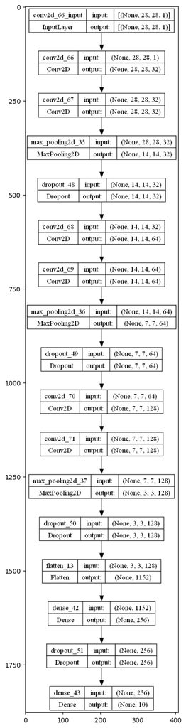

```python
plot_model(cnn_16_layers, to_file='neuro_models/model_plot_cnn_16.png', show_shapes=True, show_layer_names=True)

img_cnn_16 = plt.imread('neuro_models/model_plot_cnn_16.png')
fig, ax = plt.subplots(figsize=(20, 20))
ax.imshow(img_cnn_16)
plt.show()
```

We can clearly see that this model is the most complex one out of all three. Now, let's compile it.

```python
cnn_16_layers.compile(optimizer='adam', loss='categorical_crossentropy', metrics=['accuracy'])
```

### 🖼️ Data Augmentation

Now, we are going to incorporate data augmentation using the ImageDataGenerator to enhance the robustness and generalization of the neural network model. I have decided to incorporate data augmentation only for the 16-layer CNN model. The purpose of this is to make our final model as good as possible, using different techniques. Data augmentation involves applying various transformations to our existing dataset, creating new, slightly modified versions of the images. This helps the model become more resilient to diverse writing styles and orientations, reducing the risk of overfitting to specific patterns in the training data. The specified transformations, such as random rotations, zooming, and shifts, simulate real-world variations in handwritten digits. By exposing the model to these augmented images during training, we aim to improve its ability to accurately recognize digits in varying conditions, ultimately enhancing its performance on unseen data.

Now that we have explained the importance of data augmentation, it is important to note that there are different parameters of the 'ImageDataGenerator'. Let's delve into our parameters and see what they mean:

- featurewise_center / samplewise_center: These parameters control whether to center the pixel values of the entire dataset or each individual sample around zero.
- featurewise_std_normalization / samplewise_std_normalization: These parameters control whether to normalize the pixel values of the entire dataset or each individual sample based on their standard deviation.
- zca_whitening: This is a method that linearly decorrelates features.
- rotation_range: Randomly rotates images within the specified range. In our case 10 degrees.
- zoom_range: Randomly zooms into or out of images.
- width_shift_range / height_shift_range: Randomly shifts images horizontally or vertically. In our case, the parameters are set to 0.1, which means that image can be shifted horizontally or vertically by a maximum of 10% of its total width.
- horizontal_flip / vertical_flip: Randomly flips images horizontally or vertically.

```python
datagen = ImageDataGenerator(
        featurewise_center=False,
        samplewise_center=False,
        featurewise_std_normalization=False,
        samplewise_std_normalization=False,
        zca_whitening=False,
        rotation_range=10,
        zoom_range = 0.1,
        width_shift_range=0.1,
        height_shift_range=0.1,
        horizontal_flip=False,
        vertical_flip=False
        )
```

```python
datagen.fit(X_train_cnn)
```

After the incorporation of data augmentation, it is time to fit the model.

```python
cnn_16_layers_history = cnn_16_layers.fit(datagen.flow(X_train_cnn, y_train, batch_size=64), epochs=10, validation_data=(X_test_cnn, y_test))
# cnn_16_layers_history = cnn_16_layers.fit(X_train_cnn, y_train, epochs=10, batch_size=64, validation_data=(X_test_cnn, y_test))
```

### 🧐 Evaluation

```python
test_loss_cnn_16, test_accuracy_cnn_16 = cnn_16_layers.evaluate(X_test_cnn, y_test)
print(f'Test Accuracy: {test_accuracy_cnn_16}')
```

```
Test Accuracy: 0.9943000078201294
```

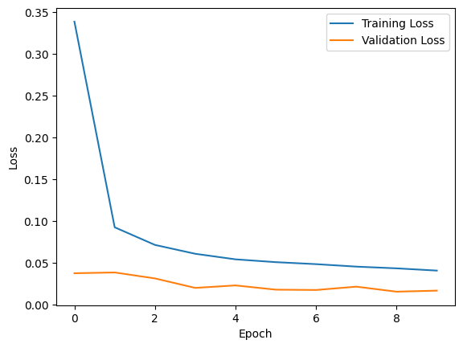

```python
plot_loss(cnn_16_layers_history)
```

```python
predictions_cnn_16 = cnn_16_layers.predict(X_test_cnn)
```

```python
true_labels_cnn_16 = np.argmax(y_test, axis=1)
predicted_labels_cnn_16 = np.argmax(predictions_cnn_16, axis=1)
```

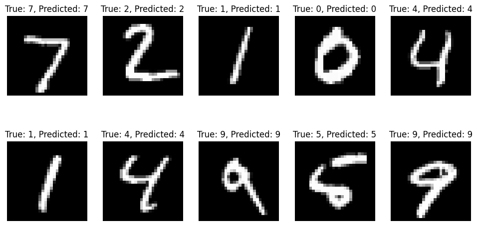

```python
plt.figure(figsize=(12, 6))
for i in range(10):
    plt.subplot(2, 5, i + 1)
    plt.imshow(X_test_cnn[i].reshape(28, 28), cmap='gray')
    plt.title(f"True: {true_labels_cnn_16[i]}, Predicted: {predicted_labels_cnn_16[i]}")
    plt.axis('off')

plt.show()
```

```python
misclassified_indices = np.where(predicted_labels_cnn_16 != true_labels_cnn_16)[0]
```

```python
misclassified_predictions = predicted_labels_cnn_16[misclassified_indices]
```

```python
misclassified_predictions.sum()
```

```
286
```

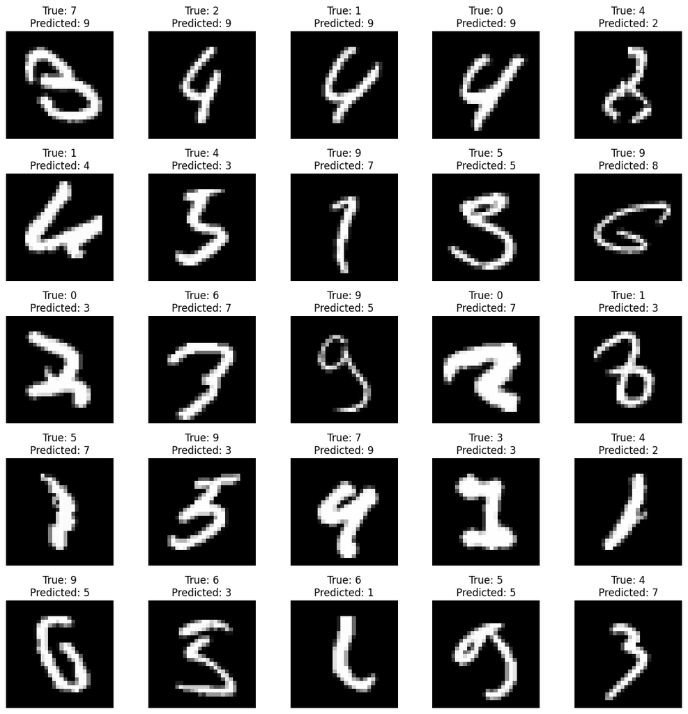

```python
num_rows = 5
num_cols = 5
num_images = num_rows * num_cols

plt.figure(figsize=(12, 12))

for i in range(num_images):
    plt.subplot(num_rows, num_cols, i + 1)
    plt.imshow(X_test_cnn[misclassified_indices[i]].reshape((28, 28)), cmap='gray')
    plt.title(f'True: {true_labels[i]}\nPredicted: {misclassified_predictions[i]}')
    plt.axis('off')

plt.tight_layout()
plt.show()
```

In conclusion, our exploration of neural networks revealed a progression in model performance. The initial feedforward neural network served as a solid introduction, demonstrating satisfactory results despite its simplicity. Moving to our first convolutional neural network (CNN) marked a significant improvement, showcasing enhanced accuracy and reduced errors. CNNs, known for their prowess in image recognition, proved highly effective in our digit recognition task. The first CNN model showed extremely good results and proved that simplicity sometimes leads to really good results. However, the pinnacle of our exploration was the final CNN model, boasting 16 layers and coupled with Data Augmentation. This model achieved the best results, minimizing errors and affirming the power of deeper architectures and data augmentation techniques. It's essential to acknowledge once again that some digits in the dataset pose challenges even for human recognition, emphasizing the significance of the achieved results. Collectively, all three models played pivotal roles in our tasks of digit recognition and in-depth exploration of neural networks.

## 📝 Demonstration and Feedback

### Demonstration

This chapter will be dedicated to the Demonstration to my stakeholder (Denitsa Goranova) and the feedback that I received. For the demonstration, this time, I decided on showing the notebook and explaining the final model. This decision is firstly based on the fact that my stakeholder is also a student with an AI specialization, so there is no particular need of an application. The other reason for the absence of an application to demonstrate the work of the model, is the time for the project. If the project were to be continued, then a proper application can be created.

- When?

The demonstration to the stakeholder will take place on 22/01/2024.

- Demonstration plan

Introduction: I will provide a quick overview of the end model and its perfomance.

Demonstrating the notebook: I will explain the process thoroughly, as well as my decisions and the reasonings behind them. I will conclude with my general findings and the knowledge I gained regarding the topic and neural networks.

Q&A: I will give time to my stakeholder to ask any final questions and I will answer them. The questions that I will be expecting are regarding the process or the possible future improvements.

### Feedback

Throughout the project development, I had 3 meetings in total with my stakeholder (Denitsa Goranova) including the demonstration.

- First Stakeholder Meeting

At the first meeting, I had just started the project and had done my research. I showcased my findings and initial version of the notebook. Denitsa was extremely happy with what I have found. She had no previous idea of neural networks, and when I showed her my initial progress, including the Domain Understanding, she was able to quickly get and idea of what neural networks are and how they can work for digit recogntion. Overall, the first feedback that I received was positive with no remarks.

- Second Stakeholder Meeting

At the second meeting, I had already finished the Data Provisionsing, as well as implemented most of the models. I explained to Denitsa my progress and my decisions regarding the actions that i made. Her feedback was again positive, as she also noted that it was a really good decision to explore the way every digit is written, because it shows the variations in handwriting styles and how they can affect the performance of the model. She appreciated the comprehensive approach taken during the Data Provisioning and the implmentation of diverse models. Lastly, she expressed that my explanations are clear and it is easy to understand what and why I am doing.

- Third Stakeholder Meeting (Demonstration)

At this final meeting, I showed my stakeholder the finished notebook. I explained to her which model works best and why. She was impressed with the work that I have done. After my demonstration, we also discussed some future improvements, as she asked me what I think can happen further in this project. We discussed the possibility to include letters and special characters as well. Overall, the final meeting was a success. My stakeholder was pleased with the results. She managed to understand my approach and my decisions throughout the whole notebook.

## 📚 References

IBM. (n.d.). Neural Networks. Retrieved from https://www.ibm.com/topics/neural-networks

Amazon Web Services, Inc. (n.d.). What is a Neural Network? Retrieved from https://aws.amazon.com/what-is/neural-network/

Patel, A. (2021, June 11). Why Convolution Neural Networks are Better Than Feed-Forward Networks: Introduction. Analytics Vidhya. Retrieved from https://medium.com/analytics-vidhya/why-convolution-neural-networks-are-better-than-feed-forward-networks-introduction-58edf65b830e